# Lab 3 — recommender systems

#### Group: Q

#### Names:

Luka Secilmis  
Thomas Ecabert  
Aymeric Bacuet  
Berkay Güler

```python
import json
import matplotlib.pyplot as plt
import numpy as np
import operator
from pyspark.mllib.recommendation import ALS, Rating
from operator import itemgetter
import pickle
from bokeh.io import show, output_notebook
from bokeh.plotting import figure, ColumnDataSource
from bokeh.models import HoverTool, ResetTool, PanTool, WheelZoomTool, SaveTool
output_notebook()

%matplotlib inline
plt.style.use("ggplot")
```

What does the data look like?

```python
!hdfs dfs -cat /ix/ml-20m/ratings.txt | tail -n 2
```

```
WARNING: log4j.properties is not found. HADOOP_CONF_DIR may be incomplete.
{"movieId": 70286, "userId": 138493, "timestamp": 1258126944, "rating": 5.0}
{"movieId": 71619, "userId": 138493, "timestamp": 1255811136, "rating": 2.5}
```

```python
movie_data = sc.textFile("/ix/ml-20m/movies.txt").map(json.loads)
```

```python
data = sc.textFile("/ix/ml-20m/ratings.txt").map(json.loads)
```

```python
movie2name = dict(movie_data.map(itemgetter("movieId", "title")).collect())
```

### 3.5 Basic Statistics

```python
# Number of ratings per user and per item
ratings_per_user = data.map(lambda x: (x['userId'], 1)).groupByKey().mapValues(lambda v: len(v)).sortByKey().collect()
ratings_per_item = data.map(lambda x: (x['movieId'], 1)).groupByKey().mapValues(lambda v: len(v)).sortByKey().collect()
```

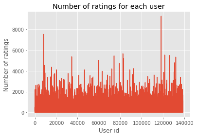

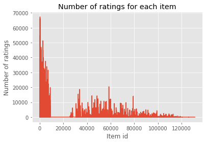

```python
# We plot both of these
plt.plot(*zip(*ratings_per_user))
plt.title('Number of ratings for each user')
plt.ylabel('Number of ratings')
plt.xlabel('User id')
plt.show()

plt.plot(*zip(*ratings_per_item))
plt.title('Number of ratings for each item')
plt.ylabel('Number of ratings')
plt.xlabel('Item id')
plt.show()
```

#### Is the number of ratings balanced uniformly across users and movies?\

Neither the number of ratings for each user nor the number of ratings for each item seem to be uniformly balanced. However the ratings for each user are almost uniformly balanced, with the exception of a few users who have rated many more movies than other users (in the 7000-1000s).\ The ratings per item are not uniformly balanced at all as there are items that have very high number of ratings (around 70000) while many other items have very little ratings (below 5000).

### 3.6 Partitioning the dataset

```python
# Append my ratings to the data RDD
# Unfortunately I had to do this manually as jupyter could not find my 'my-ratings.txt' file
# I even tried to upload it to hdfs but it didn't work. I think it is an access control problem with my mac.
# But the TAs suggestion on the forum did unfortunately not work either.

my_ratings = sc.parallelize([{"movieId": 1, "userId": 138494, "timestamp": 1651666557, "rating": 5},
{"movieId": 780, "userId": 138494, "timestamp": 1651666558, "rating": 4},
{"movieId": 1210, "userId": 138494, "timestamp": 1651666562, "rating": 5},
{"movieId": 648, "userId": 138494, "timestamp": 1651666563, "rating": 4},
{"movieId": 344, "userId": 138494, "timestamp": 1651666566, "rating": 1},
{"movieId": 165, "userId": 138494, "timestamp": 1651666568, "rating": 3},
{"movieId": 153, "userId": 138494, "timestamp": 1651666569, "rating": 2},
{"movieId": 1580, "userId": 138494, "timestamp": 1651666573, "rating": 4},
])

# Append my ratings to data by taking the union of both
data = data.union(my_ratings)

# Partition the data into a training set and a validation set randomly
training, validation = data.randomSplit([0.8, 0.2])
```

### 3.7 Baseline Model

```python
# Global_average_rating
mean = training.map(lambda x: x['rating']).mean()

# User biases as dictionary
u = training.map(lambda x: (x['userId'], x['rating'])).groupByKey().mapValues(list)
alphas = dict(u.map(lambda r: (r[0], (sum(r[1])/len(r[1])) - mean)).collect())

# Remaining item biases as dictionary
i = training.map(lambda x: (x['movieId'], x['rating'] - alphas[x['userId']])).groupByKey().mapValues(list)
betas = dict(i.map(lambda r: (r[0], (sum(r[1])/len(r[1])) - mean)).collect())
```

```python
# Number of parameters = n users + m items
print(f'This model has {len(alphas) + len(betas)} parameters')
```

```
This model has 164329 parameters
```

```python
# Default alpha/beta values - simply the mean of all alphas/betas
default_alpha = np.mean(np.array(list(alphas.values())))
default_beta = np.mean(np.array(list(betas.values())))

# Predictions using baseline model
validation_predictions = [[p[0], p[1], alphas.get(p[1], default_alpha) + betas.get(p[0], default_beta) + mean] for p in validation.map(lambda x: [x["movieId"],x["userId"]]).collect()]
validation_predictions = sc.parallelize(validation_predictions).map(lambda p: {'movieId': p[0], 'userId': p[1], 'rating':p[2]})
```